#### GLMM Model Selection

##### Model Selection

###### Seedlings

```r
library(tidyverse)
library(lme4) # for lmer
library(sjPlot) # for cleaned up anova table
library(car) # for VIF
library(AICcmodavg) # for delta AIC

options(scipen = 100, digits = 4)

comb_df <- read.csv("../data/regression_data_2016-2019.csv") %>%
  mutate(DBI2 = ifelse(DBI <= 3, 3, DBI)) %>%
  rename(physio = Physiographic_Class, prov = PROVINCE)
```

**Model Selection**

```r
# Calc constant for log transforming with 0s
miny_sd <- min(comb_df$Seed_Dens_NatCan[comb_df$Seed_Dens_NatCan > 0])

# Null model
seed_null <- lmer(log(Seed_Dens_NatCan + miny_sd) ~ 1 + (1|Park), data = comb_df)

# Stressor only model
seed_stress <- lmer(log(Seed_Dens_NatCan + miny_sd) ~
                      as_factor(DBI2) + scale(avg.cover) + scale(hummod300m) + (1|Park),
                    data = comb_df)

# Climate change and EcoProv/physiographic model
seed_clim <- lmer(log(Seed_Dens_NatCan + miny_sd) ~ scale(tmax) + scale(precip) +
                    factor(prov) + factor(physio) + (1|Park),
                     data = comb_df)

# Structure only model
seed_fstr <- lmer(log(Seed_Dens_NatCan + miny_sd) ~
                    stage_fac + scale(QMD) +
                    scale(Tree_Dens_Total) + scale(cancov) + (1|Park),
                  data = comb_df)

# Combination model
seed_comb <- lmer(log(Seed_Dens_NatCan + miny_sd) ~
                    as_factor(DBI2) + scale(avg.cover) + factor(physio) +
                    scale(Tree_Dens_Total) + scale(cancov) + (1|Park),
                  data = comb_df)

# Combination interaction
seed_comb_int <- lmer(log(Seed_Dens_NatCan + miny_sd) ~
                    as_factor(DBI2)*scale(avg.cover) + factor(physio) +
                    scale(Tree_Dens_Total) + scale(cancov) + (1|Park),
                  data = comb_df)

# AIC table
seed_aic <- AIC(seed_null, seed_stress, seed_clim, seed_fstr, seed_comb, seed_comb_int) %>%
  arrange(AIC) #comb
```

**AIC Seedling Model table**

```
##               df  AIC
## seed_comb     11 5288
## seed_comb_int 13 5291
## seed_stress    7 5323
## seed_clim     14 5379
## seed_null      3 5384
## seed_fstr      9 5394
```

**Model diagnostics**

```r
vif(seed_comb)
```

```
##                         GVIF Df GVIF^(1/(2*Df))
## as_factor(DBI2)        1.016  2           1.004
## scale(avg.cover)       1.082  1           1.040
## factor(physio)         1.066  3           1.011
## scale(Tree_Dens_Total) 1.029  1           1.014
## scale(cancov)          1.029  1           1.014
```

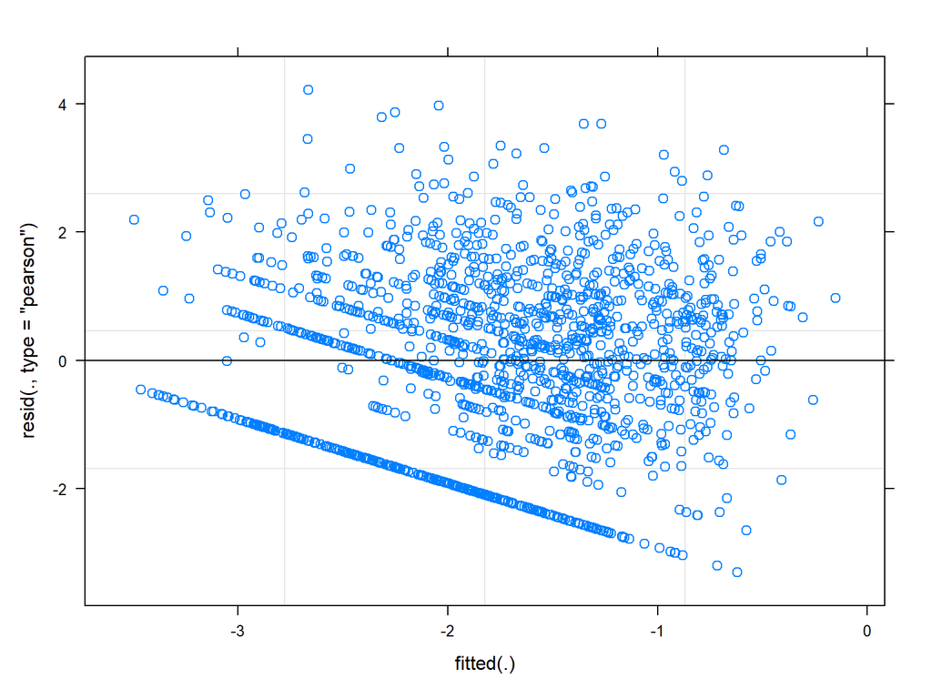

```r
plot(seed_comb)
```

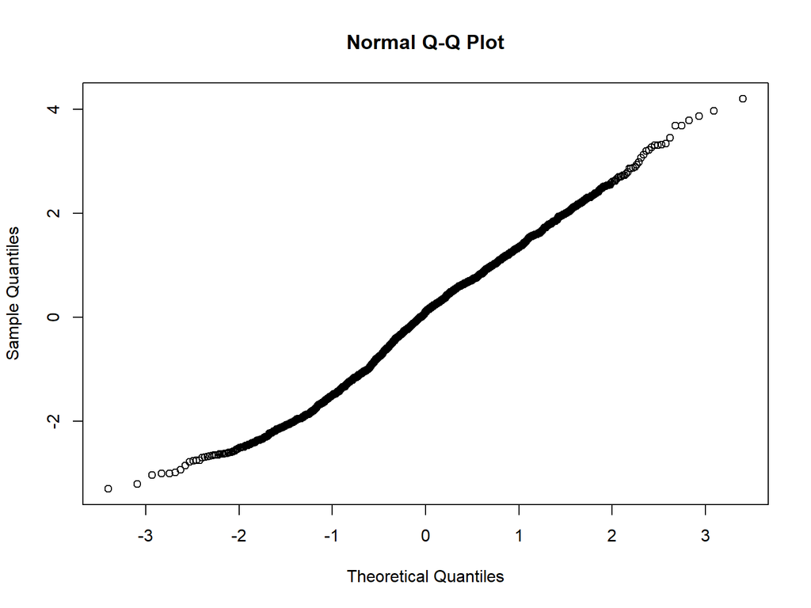

```r
qqnorm(residuals(seed_comb))
```

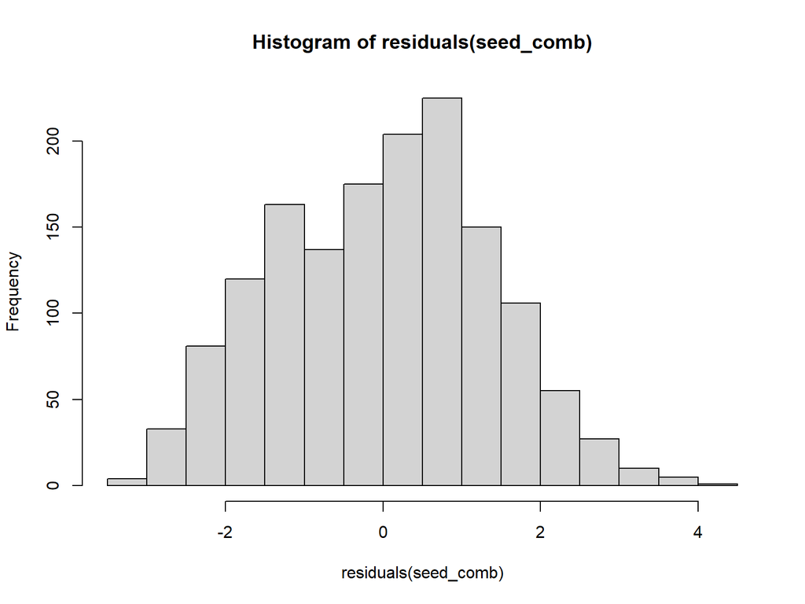

```r
hist(residuals(seed_comb))
```

###### Saplings

**Model Selection**

```r
# Calc constant for log transforming with 0s
miny_sp <- min(comb_df$Sap_Dens_NatCan[comb_df$Sap_Dens_NatCan > 0])

sap_null <- lmer(log(Sap_Dens_NatCan + miny_sp) ~ 1 + (1|Park), data = comb_df)

# Stressor only model
sap_stress <- lmer(log(Sap_Dens_NatCan + miny_sp) ~
                   as_factor(DBI2) + scale(avg.cover) + scale(hummod300m) + (1|Park),
                   data = comb_df)

# Climate change and EcoProv/physiographic model
sap_clim <- lmer(log(Sap_Dens_NatCan + miny_sp) ~ scale(tmax) + scale(precip) +
                    factor(prov) + factor(physio) + (1|Park),
                     data = comb_df)

# Structure only model
sap_fstr <- lmer(log(Sap_Dens_NatCan + miny_sp) ~ stage_fac + scale(QMD) +
                     scale(Tree_Dens_Total) + scale(cancov) +(1|Park),
                  data = comb_df)

# Combination model
sap_comb <- lmer(log(Sap_Dens_NatCan + miny_sp) ~ as_factor(DBI2) + scale(avg.cover) +
                    scale(Tree_Dens_Total) + scale(cancov) + factor(physio) +
                    (1|Park),
                  data = comb_df)

sap_comb_int <- lmer(log(Sap_Dens_NatCan + miny_sp) ~
                    as_factor(DBI2)*scale(avg.cover) + factor(physio) +
                    scale(Tree_Dens_Total) + scale(cancov) + (1|Park),
                  data = comb_df)

# AIC table
sap_aic <- AIC(sap_null, sap_stress, sap_clim, sap_fstr, sap_comb, sap_comb_int) %>%
  arrange(AIC)# comb also best model
```

**AIC Sapling Model table**

```
##              df  AIC
## sap_comb     11 4028
## sap_stress    7 4034
## sap_comb_int 13 4034
## sap_fstr      9 4055
## sap_clim     14 4060
## sap_null      3 4087
```

**Model diagnostics**

```r
vif(sap_comb)
```

```
##                         GVIF Df GVIF^(1/(2*Df))
## as_factor(DBI2)        1.016  2           1.004
## scale(avg.cover)       1.079  1           1.039
## scale(Tree_Dens_Total) 1.028  1           1.014
## scale(cancov)          1.027  1           1.014
## factor(physio)         1.067  3           1.011
```

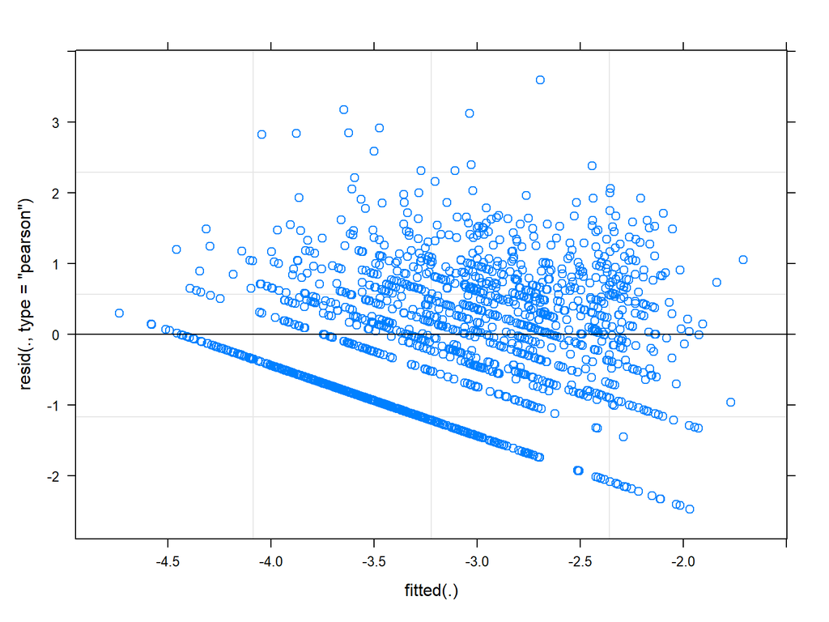

```r
plot(sap_comb)
```

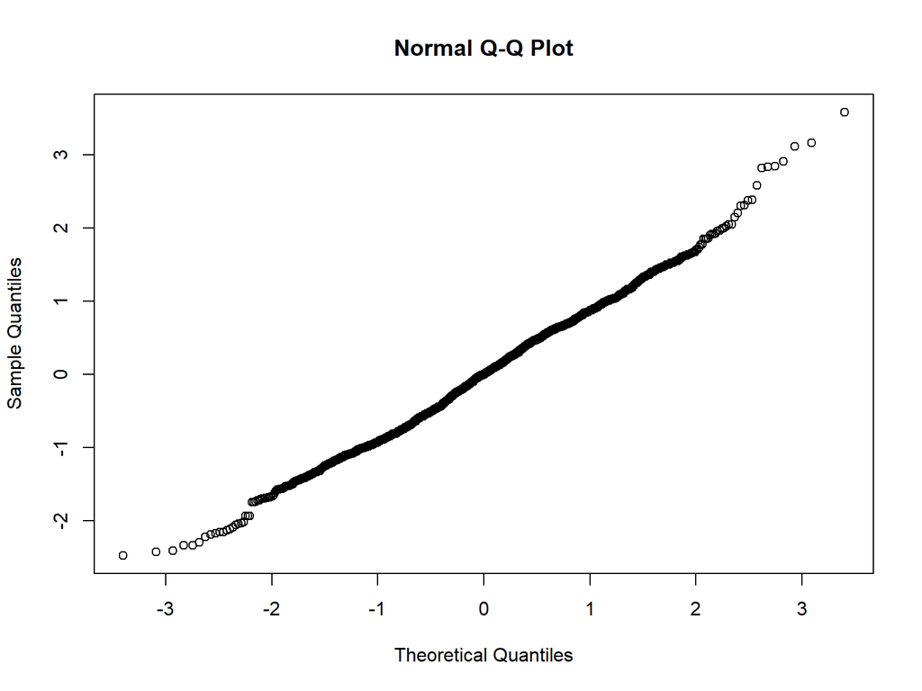

```r
qqnorm(residuals(sap_comb))
```

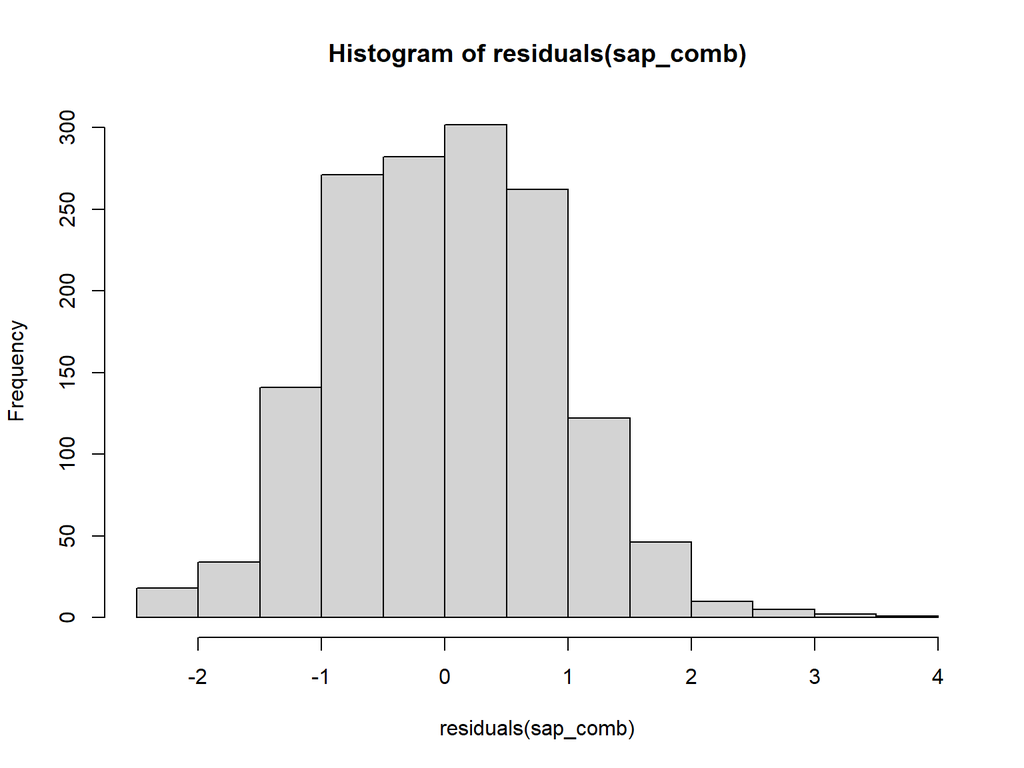

```r
hist(residuals(sap_comb))
```

**Model Output**

|  | log(Sap Dens Nat Can+miny sp) |  |  |  |
| --- | --- | --- | --- | --- |
| Predictors | Estimates | std. Error | CI | p |
| (Intercept) | -2.86 | 0.10 | -3.05 – -2.67 | **<0.001** |
| DBI2 [4] | -0.24 | 0.06 | -0.35 – -0.12 | **<0.001** |
| DBI2 [5] | -0.30 | 0.08 | -0.46 – -0.14 | **<0.001** |
| avg cover | -0.18 | 0.03 | -0.23 – -0.12 | **<0.001** |
| Tree Dens Total | 0.09 | 0.03 | 0.03 – 0.15 | **0.004** |
| cancov | 0.00 | 0.03 | -0.05 – 0.05 | 0.884 |
| physio [dry-mesic] | -0.18 | 0.08 | -0.34 – -0.01 | **0.032** |
| physio [hydric] | -0.46 | 0.13 | -0.72 – -0.19 | **0.001** |
| physio [mesic] | -0.29 | 0.07 | -0.44 – -0.15 | **<0.001** |
| Random Effects |  |  |  |  |
| σ<sup>2</sup> | 0.80 |  |  |  |
| τ<sub>00</sub> <sub>Park</sub> | 0.13 |  |  |  |
| ICC | 0.14 |  |  |  |
| N <sub>Park</sub> | 39 |  |  |  |
| Observations | 1496 |  |  |  |
| Marginal R<sup>2</sup> / Conditional R<sup>2</sup> | 0.097 / 0.221 |  |  |  |

###### Stocking Index

**Model Selection**

```r
# Calc constant for log transforming with 0s
miny_st <- min(comb_df$stock_final[comb_df$stock_final > 0])

# Null model
stock_null <- lmer(log(stock_final + miny_st) ~ 1 + (1|Park), data = comb_df)

# Stressor only model
stock_stress <- lmer(log(stock_final + miny_st) ~ as_factor(DBI2) + scale(avg.cover) +
                       scale(hummod300m) + (1|Park),
                    data = comb_df)

# Climate change and EcoProv/physiographic model
stock_clim <- lmer(log(stock_final + miny_st) ~ scale(tmax) + scale(precip) +
                    factor(prov) + factor(physio) + (1|Park),
                     data = comb_df)

# Structure only model
stock_fstr <- lmer(log(stock_final + miny_st) ~ stage_fac + scale(QMD) +
                     scale(cancov) + scale(Tree_Dens_Total) + (1|Park),
                 data = comb_df)

# Combination model
stock_comb <- lmer(log(stock_final + miny_st) ~ as_factor(DBI2) + scale(avg.cover) + scale(cancov) +
                     scale(Tree_Dens_Total) + factor(physio) + (1|Park),
                 data = comb_df)

stock_comb_int <- lmer(log(stock_final + miny_st) ~
                    as_factor(DBI2)*scale(avg.cover) + factor(physio) +
                    scale(Tree_Dens_Total) +  scale(cancov) + (1|Park),
                  data = comb_df)

# AIC table
stock_aic <- AIC(stock_null, stock_stress, stock_clim, stock_fstr, stock_comb, stock_comb_int) %>%
  arrange(AIC) #stock_comb is best
```

**AIC Stocking Index Model table**

```
##                df  AIC
## stock_comb     11 6089
## stock_comb_int 13 6094
## stock_stress    7 6118
## stock_clim     14 6197
## stock_null      3 6218
## stock_fstr      9 6230
```

**Model diagnostics**

```r
vif(stock_comb)
```

```
##                         GVIF Df GVIF^(1/(2*Df))
## as_factor(DBI2)        1.016  2           1.004
## scale(avg.cover)       1.082  1           1.040
## scale(cancov)          1.029  1           1.014
## scale(Tree_Dens_Total) 1.029  1           1.015
## factor(physio)         1.065  3           1.011
```

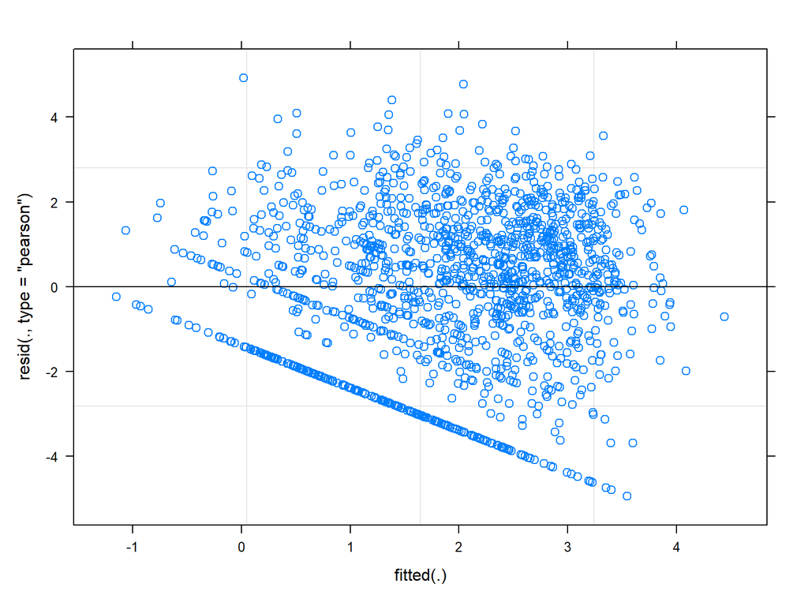

```r
plot(stock_comb)
```

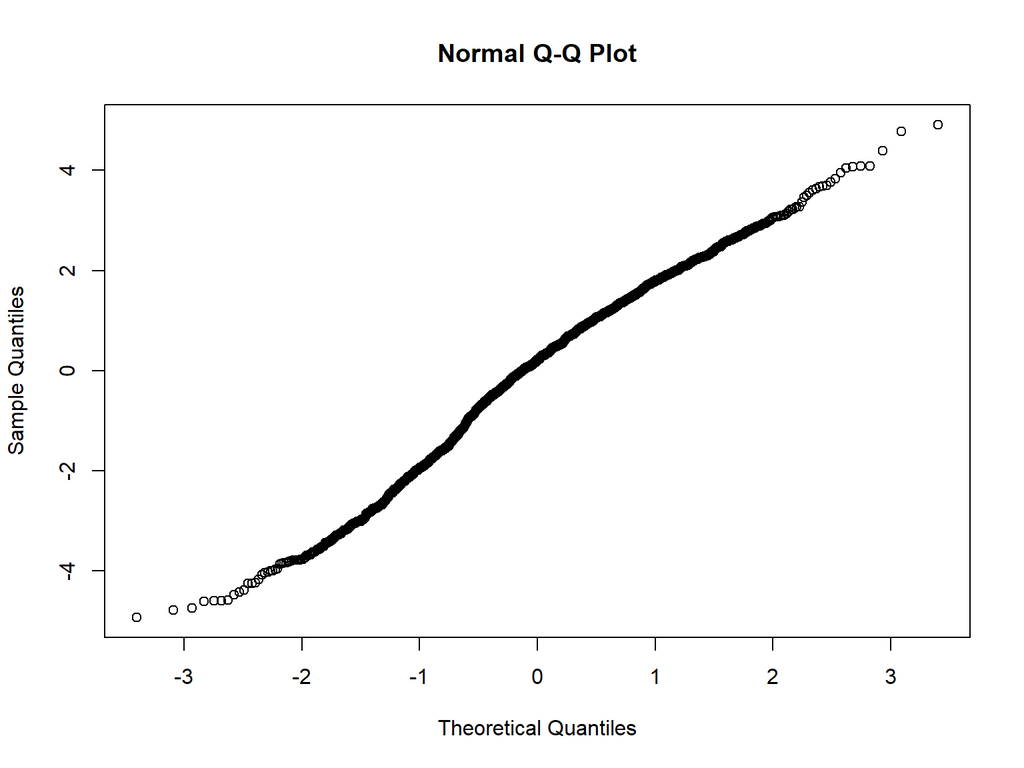

```r
qqnorm(residuals(stock_comb))
```

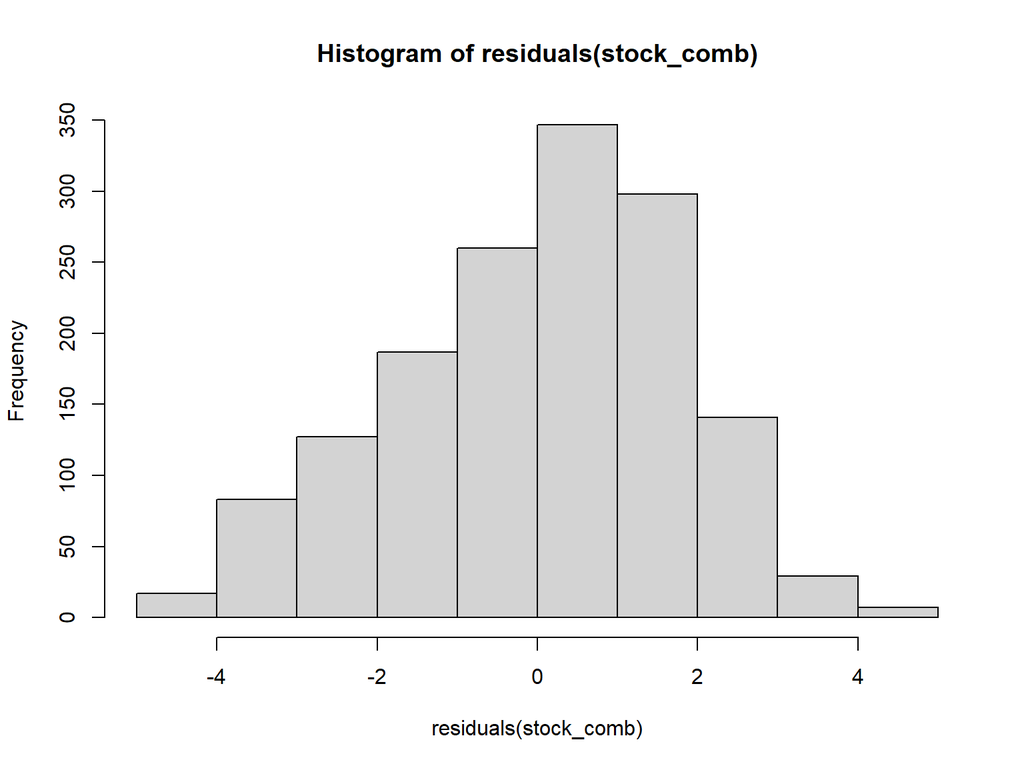

```r
hist(residuals(stock_comb))
```

**Model Output**

```r
tab_model(stock_comb, show.se = TRUE, digits = 2)
```

|  | log(stock final+miny st) |  |  |  |
| --- | --- | --- | --- | --- |
| Predictors | Estimates | std. Error | CI | p |
| (Intercept) | 2.66 | 0.18 | 2.30 – 3.02 | **<0.001** |
| DBI2 [4] | -0.68 | 0.12 | -0.92 – -0.44 | **<0.001** |
| DBI2 [5] | -1.48 | 0.16 | -1.80 – -1.16 | **<0.001** |
| avg cover | -0.31 | 0.06 | -0.42 – -0.20 | **<0.001** |
| cancov | -0.08 | 0.05 | -0.18 – 0.02 | 0.133 |
| Tree Dens Total | -0.24 | 0.06 | -0.35 – -0.12 | **<0.001** |
| physio [dry-mesic] | 0.08 | 0.16 | -0.24 – 0.40 | 0.642 |
| physio [hydric] | -1.05 | 0.27 | -1.58 – -0.52 | **<0.001** |
| physio [mesic] | -0.53 | 0.15 | -0.82 – -0.24 | **<0.001** |
| Random Effects |  |  |  |  |
| σ<sup>2</sup> | 3.22 |  |  |  |
| τ<sub>00</sub> <sub>Park</sub> | 0.37 |  |  |  |
| ICC | 0.10 |  |  |  |
| N <sub>Park</sub> | 39 |  |  |  |
| Observations | 1496 |  |  |  |
| Marginal R<sup>2</sup> / Conditional R<sup>2</sup> | 0.126 / 0.217 |  |  |  |

###### Sorensen Seedlings

**Model Selection**

```r
# Null model
sorseed_null <- lmer(Sor_seed ~ 1 + (1|Park), data = comb_df)

# Stressor only model
sorseed_stress <- lmer(Sor_seed ~ as_factor(DBI2) + scale(avg.cover) +
                         scale(hummod300m) + (1|Park),
                    data = comb_df)

# Climate change and EcoProv/physiographic model
sorseed_clim <- lmer(Sor_seed ~ scale(tmax) + scale(precip) +
                    factor(prov) + factor(physio) + (1|Park),
                     data = comb_df)

# Structure only model
sorseed_fstr <- lmer(Sor_seed ~ stage_fac + scale(QMD) +
                    scale(Tree_Dens_Total) + scale(cancov) + (1|Park),
                  data = comb_df)

# Combination model
sorseed_comb <- lmer(Sor_seed ~ #scale(precip) + scale(tmax) +
                    as_factor(DBI2) + scale(avg.cover) + scale(cancov) +
                     scale(Tree_Dens_Total) + #scale(Tree_BA_Total)  high VIF when included
                     factor(physio) + (1|Park),
                 data = comb_df)

# Combination interaction
sorseed_comb_int <- lmer(Sor_seed  ~
                      as_factor(DBI2)*scale(avg.cover) + factor(physio) +
                    scale(Tree_Dens_Total) + scale(cancov) + (1|Park),
                  data = comb_df)

# AIC table
sorseed_aic <- AIC(sorseed_null, sorseed_stress, sorseed_clim, sorseed_fstr,
                   sorseed_comb, sorseed_comb_int) %>% arrange(AIC)
# stress model best
```

**AIC Sorensen Seedling Model table**

```
##                  df    AIC
## sorseed_stress    7 -391.3
## sorseed_comb     11 -390.7
## sorseed_comb_int 13 -381.2
## sorseed_null      3 -369.7
## sorseed_clim     14 -357.1
## sorseed_fstr      9 -327.7
```

**Model diagnostics**

```r
vif(sorseed_stress)
```

```
##                    GVIF Df GVIF^(1/(2*Df))
## as_factor(DBI2)   1.013  2           1.003
## scale(avg.cover)  1.048  1           1.024
## scale(hummod300m) 1.041  1           1.020
```

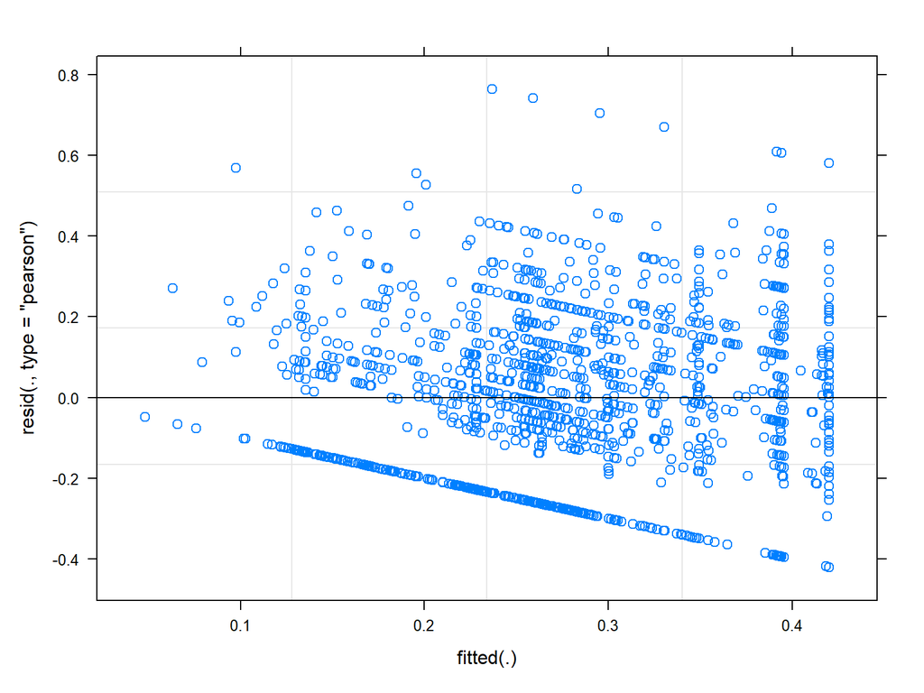

```r
plot(sorseed_stress)
```

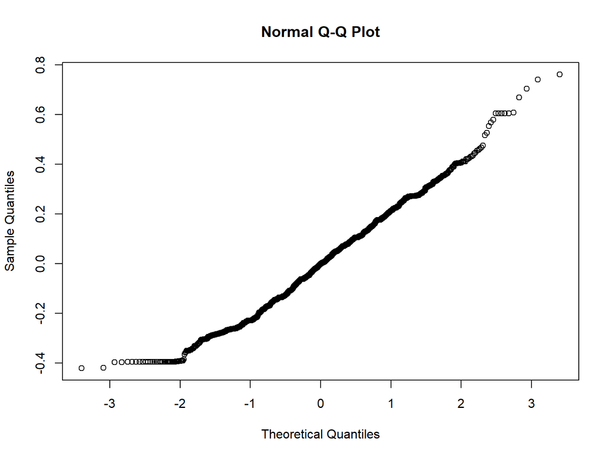

```r
qqnorm(residuals(sorseed_stress))
```

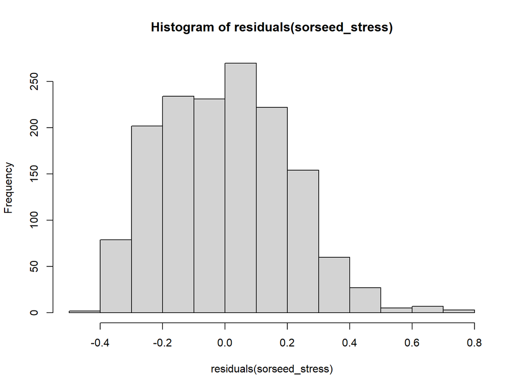

```r
hist(residuals(sorseed_stress))
```

**Model Output**

```r
tab_model(sorseed_stress, show.se = TRUE, digits = 2)
```

|  | Sor seed |  |  |  |
| --- | --- | --- | --- | --- |
| Predictors | Estimates | std. Error | CI | p |
| (Intercept) | 0.30 | 0.01 | 0.27 – 0.33 | **<0.001** |
| DBI2 [4] | -0.03 | 0.01 | -0.05 – 0.00 | 0.055 |
| DBI2 [5] | -0.12 | 0.02 | -0.15 – -0.08 | **<0.001** |
| avg cover | -0.02 | 0.01 | -0.04 – -0.01 | **<0.001** |
| hummod300m | -0.00 | 0.01 | -0.02 – 0.01 | 0.445 |
| Random Effects |  |  |  |  |
| σ<sup>2</sup> | 0.04 |  |  |  |
| τ<sub>00</sub> <sub>Park</sub> | 0.00 |  |  |  |
| ICC | 0.06 |  |  |  |
| N <sub>Park</sub> | 39 |  |  |  |
| Observations | 1496 |  |  |  |
| Marginal R<sup>2</sup> / Conditional R<sup>2</sup> | 0.052 / 0.112 |  |  |  |

###### Sorensen Saplings

**Model Selection**

```r
# Null model
sorsap_null <- lmer(Sor_sap ~ 1 + (1|Park), data = comb_df)

# Stressor only model
sorsap_stress <- lmer(Sor_sap ~ as_factor(DBI2) + scale(avg.cover) +
                         scale(hummod300m) + (1|Park),
                   data = comb_df)

# Climate change and EcoProv/physiographic model
sorsap_clim <- lmer(Sor_sap ~ scale(tmax) + scale(precip) +
                    factor(prov) + factor(physio) + (1|Park),
                data = comb_df)

# Structure only model
sorsap_fstr <- lmer(Sor_sap ~ stage_fac + scale(QMD) + #scale(Tree_BA_Total) +  #high VIF
                    scale(Tree_Dens_Total) + scale(cancov) + (1|Park),
                  data = comb_df)

# Combination model
sorsap_comb <- lmer(Sor_sap ~
                    as_factor(DBI2) + scale(avg.cover) + as_factor(physio) +
                    scale(Tree_Dens_Total) + (1|Park),
                  data = comb_df)

# Combination interaction
sorsap_comb_int <- lmer(Sor_sap  ~
                      as_factor(DBI2)*scale(avg.cover) + factor(physio) +
                      scale(Tree_Dens_Total) + (1|Park),
                    data = comb_df)

# AIC table
sorsap_aic <- AIC(sorsap_null, sorsap_stress, sorsap_clim, sorsap_fstr,
                   sorsap_comb, sorsap_comb_int) %>% arrange(AIC)
# forest structure model is best, and only model better than null
```

**AIC Sorensen sapling Model table**

```
##                 df    AIC
## sorsap_fstr      9 -459.8
## sorsap_null      3 -418.4
## sorsap_comb     10 -412.8
## sorsap_stress    7 -403.0
## sorsap_comb_int 12 -396.7
## sorsap_clim     14 -384.9
```

**Model diagnostics**

```r
vif(sorsap_fstr)
```

```
##                         GVIF Df GVIF^(1/(2*Df))
## stage_fac              1.651  3           1.087
## scale(QMD)             1.707  1           1.306
## scale(Tree_Dens_Total) 1.278  1           1.131
## scale(cancov)          1.080  1           1.039
```

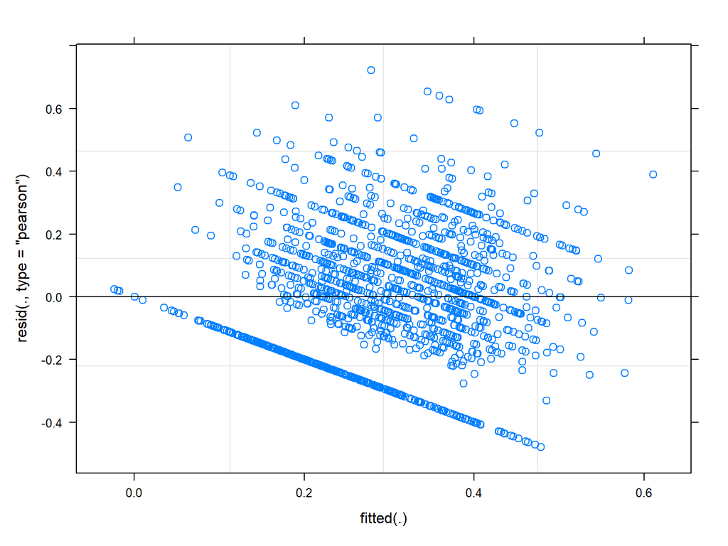

```r
plot(sorsap_fstr)
```

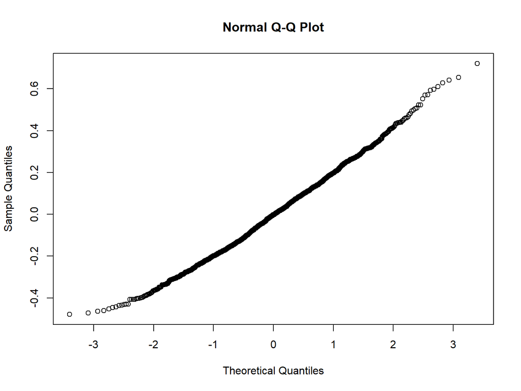

```r
qqnorm(residuals(sorsap_fstr))
```

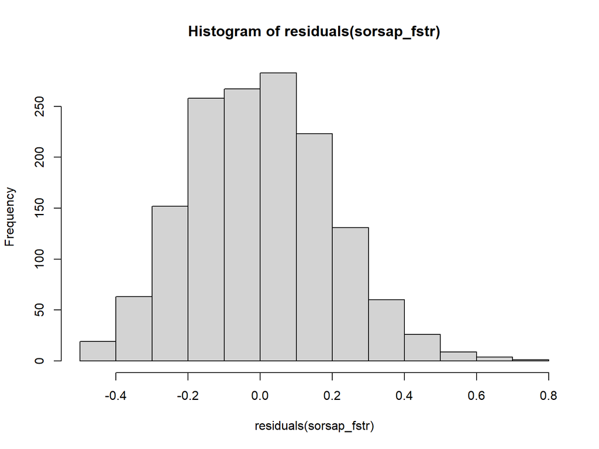

```r
hist(residuals(sorsap_fstr))
```

**Model Output**

```r
tab_model(sorsap_fstr, show.se = TRUE, digits = 2)
```

|  | Sor sap |  |  |  |
| --- | --- | --- | --- | --- |
| Predictors | Estimates | std. Error | CI | p |
| (Intercept) | 0.30 | 0.02 | 0.27 – 0.33 | **<0.001** |
| stage fac [Mature] | -0.04 | 0.01 | -0.07 – -0.02 | **0.003** |
| stage fac [Mosaic] | -0.03 | 0.02 | -0.06 – 0.01 | 0.125 |
| stage fac [Pole] | 0.02 | 0.02 | -0.03 – 0.07 | 0.414 |
| QMD | -0.05 | 0.01 | -0.06 – -0.03 | **<0.001** |
| Tree Dens Total | 0.02 | 0.01 | 0.01 – 0.04 | **0.004** |
| cancov | 0.01 | 0.01 | 0.00 – 0.02 | **0.027** |
| Random Effects |  |  |  |  |
| σ<sup>2</sup> | 0.04 |  |  |  |
| τ<sub>00</sub> <sub>Park</sub> | 0.00 |  |  |  |
| ICC | 0.11 |  |  |  |
| N <sub>Park</sub> | 39 |  |  |  |
| Observations | 1496 |  |  |  |
| Marginal R<sup>2</sup> / Conditional R<sup>2</sup> | 0.080 / 0.181 |  |  |  |

###### Metric Definitions

- **DBI:** Deer browse impact (factor)
- **avg.cover:** Average % quadrat cover of all invasive species in plots collected from 2016 to 2019, calculated the same as in Miller et al. (2021) Ecological Applications 31(2):e02239
- **hummod300m:** % human modified landcover at 300m grid size based on 2016 NLCD. We used the same dataset in Miller and McGill (2019) J Appl Ecol. 56:1355–1366.
- **stage_fac:** structural stage metric that classifies a plot as Pole, Mature, LS or Mosaic (ie doesn’t fit any of the first 3) based on DBH distribution. We used this in Miller et al. (2016) Ecosphere 7(7):e01404.
- **QMD:** quadratic mean diameter
- **Tree_BA_Total:** Total basal area of live trees in sq.m/ha
- **Tree_Dens_Total:** Total density of live trees in stems/ha
- **cancov:** Percent canopy cover derived from 2016 NLCD tree canopy cover

##### Model Output/Prediction Plots

###### Prediction code

Predicting responses for all of the deer browse impact levels, 25% intervals of invasive % cover, and median values for Tree Density, Quadratic Mean Diameter, and Canopy Cover.

```r
# Function to find min, 1/4, med, 3/4 and max of a vector's range
find_range <- function(x){
  rngx <- range(comb_df[,x], na.rm = T)
  medx <- median(range(comb_df[,x]))

  vec <- c(rngx[1],
           median(c(medx, rngx[1])),
           medx,
           median(c(medx, rngx[2])),
           rngx[2]
  )
  return(vec)
}

new_df1 <- data.frame(
              expand.grid(DBI2 = c(3:5),
                          avg.cover = c(0, 25, 50, 75, 100),
                          physio = c("dry", "dry-mesic", "mesic", "hydric")),
                      Tree_Dens_Total = median(comb_df$Tree_Dens_Total),
                      cancov = median(comb_df$cancov)
              )

# Fixed effects only predictions
reg_new <- data.frame(new_df1,
                      pred_seed = predict(seed_comb, newdata = new_df1, re.form = NA),
                      pred_sap = predict(sap_comb, newdata = new_df1, re.form = NA),
                      pred_stock = predict(stock_comb, newdata = new_df1, re.form = NA))

reg_new <- reg_new %>% mutate(pred_seed_tr = exp(pred_seed) - miny_sd,
                              pred_sap_tr = exp(pred_sap) - miny_sp,
                              pred_stock_tr = exp(pred_stock) - miny_st)

dbi_cols <- c("#15C400", "#FFA600", "#E51E02")

pred_plot <- function(df, xvar, yvar, xlab, ylab, grp = "DBI2"){
  df$grp_fac <- as.factor(df[,grp])

  ggplot(df, aes_string(x = xvar, y = yvar, group = "grp_fac",
                        color = "grp_fac", shape = 'grp_fac', fill = 'grp_fac')) +
    geom_line() +
    geom_point() +
    theme_bw() +
    facet_wrap(~physio, ncol = 4) +
    scale_color_manual(values = dbi_cols,
                       labels = c("Low/Medium", "High", "Very High"),
                       name = "Deer Browse Impact") +
    scale_fill_manual(values = dbi_cols,
                      labels = c("Low/Medium", "High", "Very High"),
                      name = "Deer Browse Impact") +
    scale_shape_manual(values = c(25, 21, 24), labels = c("Low/Medium", "High", "Very High"),
                       name = "Deer Browse Impact") +
    labs(x = xlab, y = ylab) +
    theme(panel.grid = element_blank(),
          legend.position = 'bottom',
          legend.text = element_text(size = 12),
          legend.title = element_text(size = 12),
          strip.text = element_text(size = 12),
          axis.text = element_text(size = 12),
          axis.title = element_text(size = 12))

}

# DBI vs Invasive Cover
seed_plot_inv <- pred_plot(reg_new, xvar = "avg.cover", yvar = "pred_seed_tr",
                   "Average Invasive % Cover", "Seedling Density (stems/sq.m)")

sap_plot_inv <- pred_plot(reg_new, xvar = "avg.cover", yvar = "pred_sap_tr",
                   "Average Invasive % Cover", "Sapling Density (stems/sq.m)")

stock_plot_inv <- pred_plot(reg_new, xvar = "avg.cover", yvar = "pred_stock_tr",
                   "Average Invasive % Cover", "Stocking Index")

# DBI vs Tree_Dens_Total
new_df2 <- data.frame(
              expand.grid(DBI2 = c(3:5),
                          Tree_Dens_Total = find_range("Tree_Dens_Total"),
                          physio = c("dry", "dry-mesic", "mesic", "hydric")),
                          #physio = c("dry", "dry-mesic", "mesic")),
                      avg.cover = median(comb_df$avg.cover),
                      cancov = median(comb_df$cancov)
              )



# Fixed effects only predictions

reg_new2 <- data.frame(new_df2,
                       pred_seed = predict(seed_comb, newdata = new_df2, re.form = NA),
                       pred_sap = predict(sap_comb, newdata = new_df2, re.form = NA),
                       pred_stock = predict(stock_comb, newdata = new_df2, re.form = NA))

reg_new2 <- reg_new2 %>% mutate(pred_seed_tr = exp(pred_seed) - miny_sd,
                                pred_sap_tr = exp(pred_sap) - miny_sp,
                                pred_stock_tr = exp(pred_stock) - miny_st)



# DBI vs Tree Density
seed_plot_trden <- pred_plot(reg_new2, xvar = "Tree_Dens_Total", yvar = "pred_seed_tr",
                   "Tree Density (stems/ha)", "Predicted Seedling Density (stems/sq.m)")

sap_plot_trden <- pred_plot(reg_new2, xvar = "Tree_Dens_Total", yvar = "pred_sap_tr",
                   "Tree Density (stems/ha)", "Predicted Sapling Density (stems/sq.m)")

stock_plot_trden <- pred_plot(reg_new2, xvar = "Tree_Dens_Total", yvar = "pred_stock_tr",
                   "Tree Density (stems/ha)", "Predicted Stocking Index")

# DBI vs QMD
new_df3 <- data.frame(
              expand.grid(DBI2 = c(3:5),
                          QMD = find_range("QMD"),
                          physio = c("dry", "dry-mesic", "mesic", "hydric")),
                          #physio = c("dry", "dry-mesic", "mesic")),
                      avg.cover = median(comb_df$avg.cover),
                      Tree_Dens_Total = median(comb_df$Tree_Dens_Total),
                      cancov = median(comb_df$cancov)
              )

# DBI vs canopy cover
new_df3 <- data.frame(
              expand.grid(DBI2 = c(3:5),
                          cancov = find_range("cancov"),
                          physio = c("dry", "dry-mesic", "mesic", "hydric")),
                          #physio = c("dry", "dry-mesic", "mesic")),
                      avg.cover = median(comb_df$avg.cover),
                      Tree_Dens_Total = median(comb_df$Tree_Dens_Total),
                      QMD = median(comb_df$QMD)
              )

reg_new3 <- data.frame(new_df3,
                       pred_seed = predict(seed_comb, newdata = new_df3, re.form = NA),
                       pred_sap = predict(sap_comb, newdata = new_df3, re.form = NA),
                       pred_stock = predict(stock_comb, newdata = new_df3, re.form = NA))

reg_new3 <- reg_new3 %>% mutate(pred_seed_tr = exp(pred_seed) - miny_sd,
                                pred_sap_tr = exp(pred_sap) - miny_sp,
                                pred_stock_tr = exp(pred_stock) - miny_st)

# DBI vs cancov
seed_plot_can <- pred_plot(reg_new3, xvar = "cancov", yvar = "pred_seed_tr",
                   "% Canopy Cover", "Predicted Seedling Density (stems/sq.m)")

sap_plot_can <- pred_plot(reg_new3, xvar = "cancov", yvar = "pred_sap_tr",
                   "% Canopy Cover", "Predicted Sapling Density (stems/sq.m)")

stock_plot_can <- pred_plot(reg_new3, xvar = "cancov", yvar = "pred_stock_tr",
                   "% Canopy Cover", "Predicted Stocking Index")

#-- Sorensen Seedlings
# DBI vs avg cover
new_dfsor <- data.frame(
              expand.grid(DBI2 = c(3:5),
                          avg.cover = c(0, 25, 50, 75, 100)),
                          hummod300m = median(comb_df$hummod300m))

reg_newsor <- data.frame(new_dfsor, pred_seed = predict(sorseed_stress,
                                                        newdata = new_dfsor, re.form = NA))

# DBI vs avg cover
sorseed_plot_inv <-
  ggplot(reg_newsor, aes(x = avg.cover, y = pred_seed, group = as_factor(DBI2),
                         color = as_factor(DBI2)))+
    geom_line() +
    geom_point() +
    theme_bw() +
    scale_color_manual(values = dbi_cols,
                       labels = c("Low/Medium", "High", "Very High"),
                       name = "Deer Browse Impact") +
    labs(x = "Average % Invasive Cover", y = "Sorenson: Seedling vs Canopy") +
    theme(panel.grid = element_blank())


# Sorenson Saplings
# DBI vs QMD
new_dfsor2 <- data.frame(expand.grid(stage_fac = c("Late Succ.", "Mature", "Mosaic", "Pole"),
                                     QMD = find_range("QMD")),
                         Tree_Dens_Total = median(comb_df$Tree_Dens_Total),
                         cancov = median(comb_df$cancov))

reg_newsor2 <- data.frame(new_dfsor2, pred_sap = predict(sorsap_fstr, newdata = new_dfsor2, re.form = NA))

sorsap_plot_qmd <-
  ggplot(reg_newsor2, aes(x = QMD, y = pred_sap, group = stage_fac,
                        color = stage_fac)) +
    geom_line(size = 0.75) +
    geom_point(size = 2) +
    theme_bw() +
    scale_color_manual(values =c("#538645", "#60CF6C", "#6097CF", "#FCC825"),
                       labels = c("Late Successional", "Mature", "Mosaic", "Pole"),
                       name = "Structural Stage") +
    labs(x = 'Quadratic Mean Diameter (cm)', y = 'Sorenson: Sapling vs Canopy') +
    theme(panel.grid = element_blank())


# Clean up AIC tables
seed_list <- list(seed_null, seed_stress, seed_clim, seed_fstr, seed_comb, seed_comb_int)
sap_list <- list(sap_null, sap_stress, sap_clim, sap_fstr, sap_comb, sap_comb_int)
stock_list <- list(stock_null, stock_stress, stock_clim, stock_fstr, stock_comb, stock_comb_int)
sorseed_list <- list(sorseed_null, sorseed_stress, sorseed_clim, sorseed_fstr, sorseed_comb, sorseed_comb_int)
sorsap_list <- list(sorsap_null, sorsap_stress, sorsap_clim, sorsap_fstr, sorsap_comb, sorsap_comb_int)

seed_tab <- aictab(seed_list, sort = F) %>% data.frame() %>%
  mutate(model = c('seed_null', "seed_stress", "seed_clim", "seed_fstr", "seed_comb", "seed_comb_int")) %>%
  dplyr::select(model, K, AICc, Delta_AICc) #%>% arrange(Delta_AICc)

sap_tab <- aictab(sap_list, sort = F) %>% data.frame() %>%
  mutate(model = c('sap_null', "sap_stress", "sap_clim", "sap_fstr", "sap_comb", "sap_comb_int")) %>%
  dplyr::select(model, K, AICc, Delta_AICc) #%>% arrange(Delta_AICc)

stock_tab <- aictab(stock_list, sort = F) %>% data.frame() %>%
  mutate(model = c('stock_null', "stock_stress", "stock_clim", "stock_fstr", "stock_comb", "stock_comb_int")) %>%
  dplyr::select(model, K, AICc, Delta_AICc) #%>% arrange(Delta_AICc)

sorseed_tab <- aictab(sorseed_list, sort = F) %>% data.frame() %>%
  mutate(model = c('sorseed_null', "sorseed_stress", "sorseed_clim", "sorseed_fstr", "sorseed_comb", "sorseed_comb_int")) %>%
  dplyr::select(model, K, AICc, Delta_AICc) #%>% arrange(Delta_AICc)

sorsap_tab <- aictab(sorsap_list, sort = F) %>% data.frame() %>%
  mutate(model = c('sorsap_null', "sorsap_stress", "sorsap_clim", "sorsap_fstr", "sorsap_comb", "sorsap_comb_int")) %>%
  dplyr::select(model, K, AICc, Delta_AICc) #%>% arrange(Delta_AICc)
```

#### Seedlings

```r
seed_tab
```

```
##           model  K AICc Delta_AICc
## 1     seed_null  3 5384     95.521
## 2   seed_stress  7 5323     34.711
## 3     seed_clim 14 5380     91.324
## 4     seed_fstr  9 5394    106.146
## 5     seed_comb 11 5288      0.000
## 6 seed_comb_int 13 5291      2.853
```

**ANOVA Table**

Best Model: log(Seed_Dens_NatCan + miny_sd) ~ as_factor(DBI2) + scale(avg.cover) + , factor(physio) + scale(Tree_Dens_Total) + scale(cancov) + , (1 | Park)

|  | log(Seed Dens Nat Can+miny sd) |  |  |  |
| --- | --- | --- | --- | --- |
| Predictors | Estimates | std. Error | CI | p |
| (Intercept) | -1.03 | 0.14 | -1.30 – -0.75 | **<0.001** |
| DBI2 [4] | -0.46 | 0.09 | -0.64 – -0.28 | **<0.001** |
| DBI2 [5] | -1.10 | 0.12 | -1.34 – -0.86 | **<0.001** |
| avg cover | -0.10 | 0.04 | -0.18 – -0.01 | **0.025** |
| physio [dry-mesic] | -0.07 | 0.12 | -0.31 – 0.18 | 0.596 |
| physio [hydric] | -0.76 | 0.21 | -1.17 – -0.36 | **<0.001** |
| physio [mesic] | -0.53 | 0.11 | -0.75 – -0.31 | **<0.001** |
| Tree Dens Total | -0.21 | 0.05 | -0.30 – -0.12 | **<0.001** |
| cancov | 0.01 | 0.04 | -0.06 – 0.09 | 0.708 |
| Random Effects |  |  |  |  |
| σ<sup>2</sup> | 1.88 |  |  |  |
| τ<sub>00</sub> <sub>Park</sub> | 0.23 |  |  |  |
| ICC | 0.11 |  |  |  |
| N <sub>Park</sub> | 39 |  |  |  |
| Observations | 1496 |  |  |  |
| Marginal R<sup>2</sup> / Conditional R<sup>2</sup> | 0.104 / 0.202 |  |  |  |

**Prediction plots**

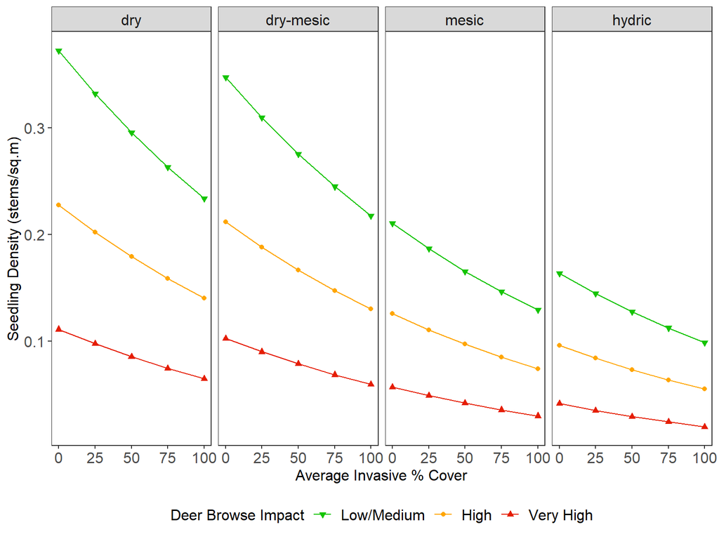

Invasive Cover vs Deer Browse Impacts and Physiographic Class for Seedling Density.

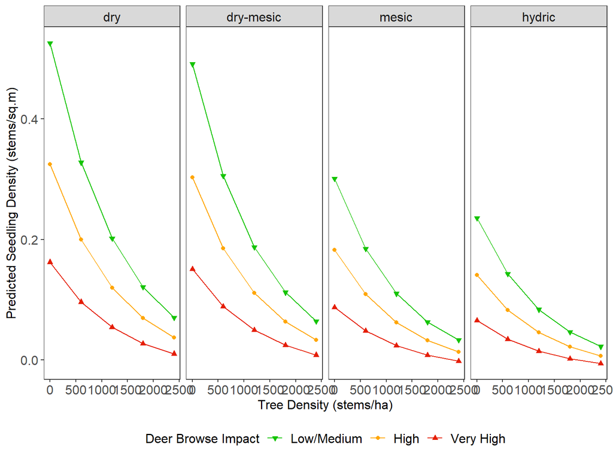

Tree Density vs Deer Browse Impacts and Physiographic Class for Seedling Density.

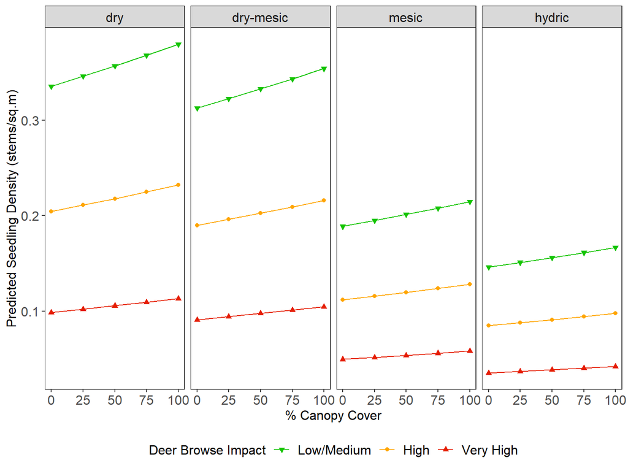

Canopy % Cover vs Deer Browse Impacts and Physiographic Class for Seedling Density.

#### Saplings

```r
sap_tab
```

```
##          model  K AICc Delta_AICc
## 1     sap_null  3 4087     59.547
## 2   sap_stress  7 4034      5.876
## 3     sap_clim 14 4061     32.778
## 4     sap_fstr  9 4055     27.327
## 5     sap_comb 11 4028      0.000
## 6 sap_comb_int 13 4034      6.363
```

**ANOVA Table**

Best Model: log(Sap_Dens_NatCan + miny_sp) ~ as_factor(DBI2) + scale(avg.cover) + , scale(Tree_Dens_Total) + scale(cancov) + factor(physio) + , (1 | Park)

|  | log(Sap Dens Nat Can+miny sp) |  |  |  |
| --- | --- | --- | --- | --- |
| Predictors | Estimates | std. Error | CI | p |
| (Intercept) | -2.86 | 0.10 | -3.05 – -2.67 | **<0.001** |
| DBI2 [4] | -0.24 | 0.06 | -0.35 – -0.12 | **<0.001** |
| DBI2 [5] | -0.30 | 0.08 | -0.46 – -0.14 | **<0.001** |
| avg cover | -0.18 | 0.03 | -0.23 – -0.12 | **<0.001** |
| Tree Dens Total | 0.09 | 0.03 | 0.03 – 0.15 | **0.004** |
| cancov | 0.00 | 0.03 | -0.05 – 0.05 | 0.884 |
| physio [dry-mesic] | -0.18 | 0.08 | -0.34 – -0.01 | **0.032** |
| physio [hydric] | -0.46 | 0.13 | -0.72 – -0.19 | **0.001** |
| physio [mesic] | -0.29 | 0.07 | -0.44 – -0.15 | **<0.001** |
| Random Effects |  |  |  |  |
| σ<sup>2</sup> | 0.80 |  |  |  |
| τ<sub>00</sub> <sub>Park</sub> | 0.13 |  |  |  |
| ICC | 0.14 |  |  |  |
| N <sub>Park</sub> | 39 |  |  |  |
| Observations | 1496 |  |  |  |
| Marginal R<sup>2</sup> / Conditional R<sup>2</sup> | 0.097 / 0.221 |  |  |  |

**Prediction plots**

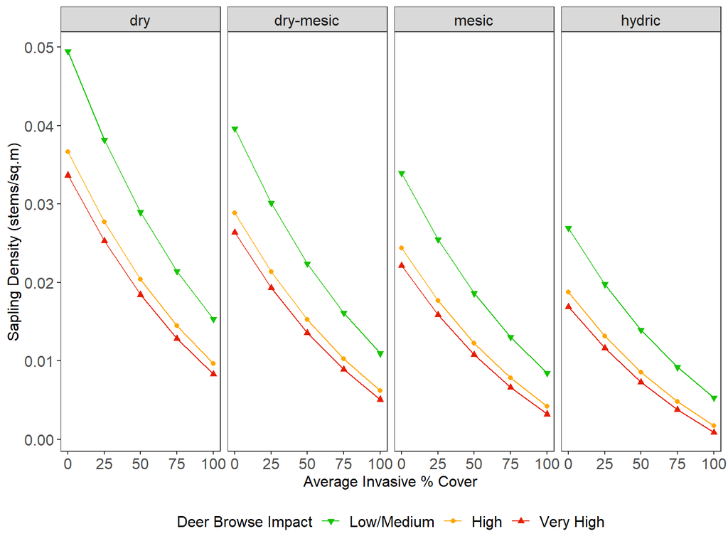

Invasive Cover vs Deer Browse Impacts and Physiographic Class for Sapling Density.

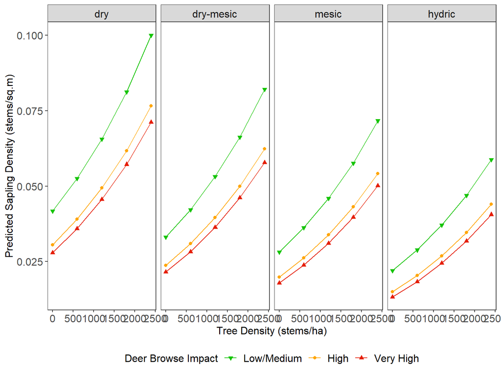

Tree Density vs Deer Browse Impacts and Physiographic Class for Sapling Density.

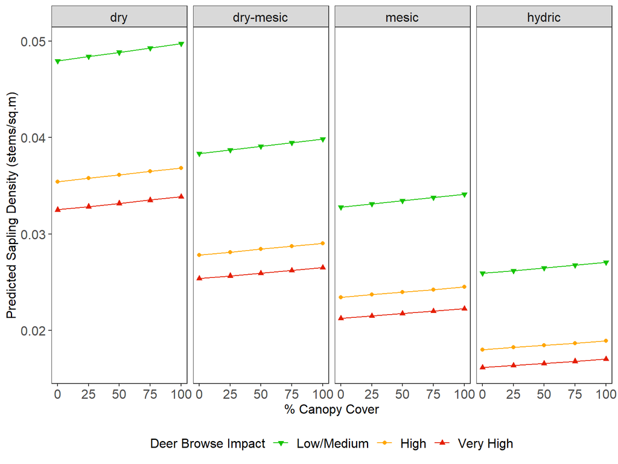

Canopy % Cover vs Deer Browse Impacts and Physiographic Class for Sapling Density.

#### Stocking Index

```r
stock_tab
```

```
##            model  K AICc Delta_AICc
## 1     stock_null  3 6218    128.610
## 2   stock_stress  7 6118     29.244
## 3     stock_clim 14 6197    108.102
## 4     stock_fstr  9 6230    141.200
## 5     stock_comb 11 6089      0.000
## 6 stock_comb_int 13 6094      5.029
```

**ANOVA Table**

Best Model: log(stock_final + miny_st) ~ as_factor(DBI2) + scale(avg.cover) + , scale(cancov) + scale(Tree_Dens_Total) + factor(physio) + , (1 | Park)

|  | log(stock final+miny st) |  |  |  |
| --- | --- | --- | --- | --- |
| Predictors | Estimates | std. Error | CI | p |
| (Intercept) | 2.66 | 0.18 | 2.30 – 3.02 | **<0.001** |
| DBI2 [4] | -0.68 | 0.12 | -0.92 – -0.44 | **<0.001** |
| DBI2 [5] | -1.48 | 0.16 | -1.80 – -1.16 | **<0.001** |
| avg cover | -0.31 | 0.06 | -0.42 – -0.20 | **<0.001** |
| cancov | -0.08 | 0.05 | -0.18 – 0.02 | 0.133 |
| Tree Dens Total | -0.24 | 0.06 | -0.35 – -0.12 | **<0.001** |
| physio [dry-mesic] | 0.08 | 0.16 | -0.24 – 0.40 | 0.642 |
| physio [hydric] | -1.05 | 0.27 | -1.58 – -0.52 | **<0.001** |
| physio [mesic] | -0.53 | 0.15 | -0.82 – -0.24 | **<0.001** |
| Random Effects |  |  |  |  |
| σ<sup>2</sup> | 3.22 |  |  |  |
| τ<sub>00</sub> <sub>Park</sub> | 0.37 |  |  |  |
| ICC | 0.10 |  |  |  |
| N <sub>Park</sub> | 39 |  |  |  |
| Observations | 1496 |  |  |  |
| Marginal R<sup>2</sup> / Conditional R<sup>2</sup> | 0.126 / 0.217 |  |  |  |

**Prediction plots**

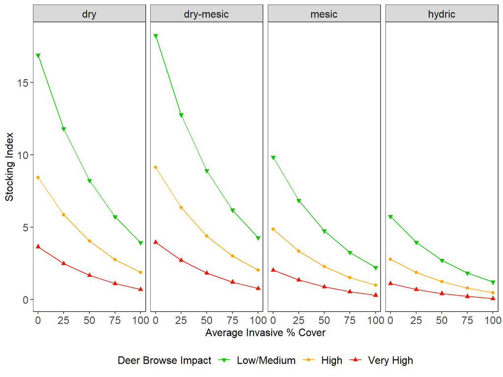

Invasive Cover vs Deer Browse Impacts and Physiographic Class for Stocking Index.

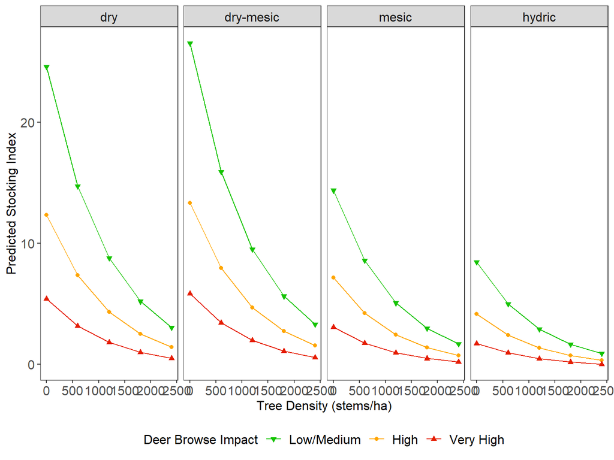

Tree Density vs Deer Browse Impacts and Physiographic Class for Stocking Index.

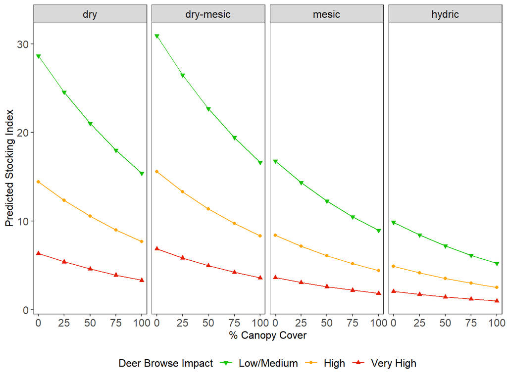

Canopy % Cover vs Deer Browse Impacts and Physiographic Class for Stocking Index.

#### Sorensen Similarity: Seedlings vs. Canopy

```r
sorseed_tab
```

```
##              model  K   AICc Delta_AICc
## 1     sorseed_null  3 -369.7    21.5367
## 2   sorseed_stress  7 -391.2     0.0000
## 3     sorseed_clim 14 -356.8    34.4464
## 4     sorseed_fstr  9 -327.6    63.6106
## 5     sorseed_comb 11 -390.6     0.6605
## 6 sorseed_comb_int 13 -380.9    10.2868
```

**ANOVA Table**

Best Model: Sor_seed ~ as_factor(DBI2) + scale(avg.cover) + scale(hummod300m) + , (1 | Park)

|  | Sor seed |  |  |  |
| --- | --- | --- | --- | --- |
| Predictors | Estimates | std. Error | CI | p |
| (Intercept) | 0.30 | 0.01 | 0.27 – 0.33 | **<0.001** |
| DBI2 [4] | -0.03 | 0.01 | -0.05 – 0.00 | 0.055 |
| DBI2 [5] | -0.12 | 0.02 | -0.15 – -0.08 | **<0.001** |
| avg cover | -0.02 | 0.01 | -0.04 – -0.01 | **<0.001** |
| hummod300m | -0.00 | 0.01 | -0.02 – 0.01 | 0.445 |
| Random Effects |  |  |  |  |
| σ<sup>2</sup> | 0.04 |  |  |  |
| τ<sub>00</sub> <sub>Park</sub> | 0.00 |  |  |  |
| ICC | 0.06 |  |  |  |
| N <sub>Park</sub> | 39 |  |  |  |
| Observations | 1496 |  |  |  |
| Marginal R<sup>2</sup> / Conditional R<sup>2</sup> | 0.052 / 0.112 |  |  |  |

**Prediction plots**

[figure not shown]

#### Sorensen Similarity: Saplings vs. Canopy

```r
sorsap_tab
```

```
##             model  K   AICc Delta_AICc
## 1     sorsap_null  3 -418.4      41.29
## 2   sorsap_stress  7 -402.9      56.74
## 3     sorsap_clim 14 -384.6      75.04
## 4     sorsap_fstr  9 -459.7       0.00
## 5     sorsap_comb 10 -412.6      47.06
## 6 sorsap_comb_int 12 -396.5      63.22
```

**ANOVA Table**

Best Model: Sor_sap ~ stage_fac + scale(QMD) + scale(Tree_Dens_Total) + scale(cancov) + , (1 | Park)

|  | Sor sap |  |  |  |
| --- | --- | --- | --- | --- |
| Predictors | Estimates | std. Error | CI | p |
| (Intercept) | 0.30 | 0.02 | 0.27 – 0.33 | **<0.001** |
| stage fac [Mature] | -0.04 | 0.01 | -0.07 – -0.02 | **0.003** |
| stage fac [Mosaic] | -0.03 | 0.02 | -0.06 – 0.01 | 0.125 |
| stage fac [Pole] | 0.02 | 0.02 | -0.03 – 0.07 | 0.414 |
| QMD | -0.05 | 0.01 | -0.06 – -0.03 | **<0.001** |
| Tree Dens Total | 0.02 | 0.01 | 0.01 – 0.04 | **0.004** |
| cancov | 0.01 | 0.01 | 0.00 – 0.02 | **0.027** |
| Random Effects |  |  |  |  |
| σ<sup>2</sup> | 0.04 |  |  |  |
| τ<sub>00</sub> <sub>Park</sub> | 0.00 |  |  |  |
| ICC | 0.11 |  |  |  |
| N <sub>Park</sub> | 39 |  |  |  |
| Observations | 1496 |  |  |  |
| Marginal R<sup>2</sup> / Conditional R<sup>2</sup> | 0.080 / 0.181 |  |  |  |

**Prediction plots**

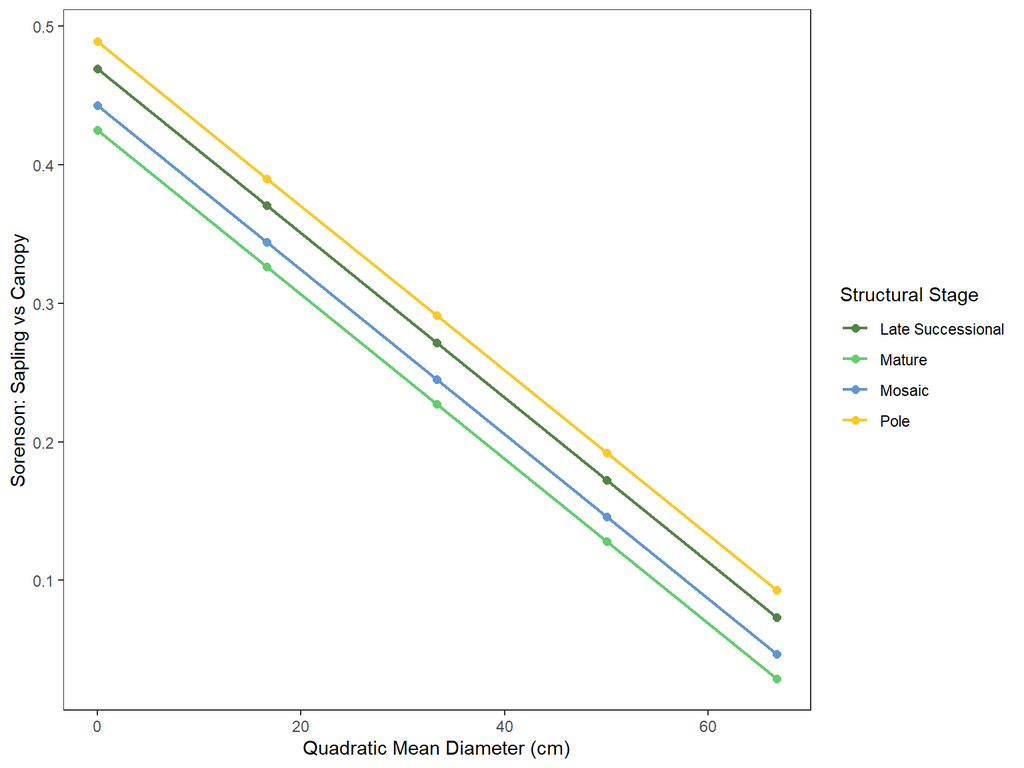

Structural Stage vs. Quadratic Mean Diameter for Sapling vs. Canopy Similarity.